# Análisis de datos de hipertensión y actividad física

Carlos de Oro Aguado

2024-11-15

## Análisis de validación del instrumento

```
##
## Reliability analysis
##  raw_alpha std.alpha G6(smc) average_r S/N    ase mean   sd median_r
##       0.94      0.95    0.97      0.32  19 0.0048  4.5 0.46     0.32
```

Los resultados muestran que el instrumento tiene una **alta confiabilidad** en términos de consistencia interna, con un **coeficiente alfa de Cronbach** superior a **0.94** y una correlación entre ítems moderada. Esto sugiere que el instrumento mide de manera consistente el constructo que se propone evaluar. Además, la relación **señal/ruido** y el **error estándar bajo** refuerzan la precisión de las mediciones. Con una **media de 4.51** y una **baja desviación estándar de 0.4644**, se puede concluir que los participantes tienden a estar en su mayoría de acuerdo con las afirmaciones del instrumento, lo que refleja un patrón de respuestas consistente. Estos resultados respaldan la fiabilidad y la validez del instrumento como herramienta para medir el constructo de interés.

## Análisis de datos

|  | Total | Promedio_Edad | DesviacionEstandar_Edad | Mediana_Edad | Minimo_Edad | Maximo_Edad |
| --- | --- | --- | --- | --- | --- | --- |
| 1 | 260 | 9.66 | 0.96 | 10 | 8 | 11 |

La muestra tiene un total de 260 registros, cuya edad promedio es de 9.66 años (desv. estandar = 0.96 años), donde el $50\%$ de los niños tiene edad menor o igual a 10 años. Además, la edad de mínima de los niños es de 8 años y máxima de 11 años.

|  | Sexo | Frecuencia | Porcentaje |
| --- | --- | --- | --- |
| 1 | Femenino | 129 | 49.62 |
| 2 | Masculino | 131 | 50.38 |

Ahora, el 50.38 % son del sexo masculino y el resto del sexo femenino.

Ahora realicemos una tabla de la edad según el sexo

|  | Sexo | Total | Promedio_Edad | DesviacionEstandar_Edad | Mediana_Edad | Minimo_Edad | Maximo_Edad |
| --- | --- | --- | --- | --- | --- | --- | --- |
| 1 | Femenino | 129 | 9.59 | 0.92 | 10 | 8 | 11 |
| 2 | Masculino | 131 | 9.73 | 0.98 | 10 | 8 | 11 |

La tabla anterior nos muestra de la variable edad según el sexo, donde se tiene una distribución homogénea en ambos grupos. En el grupo femenino (n=129), la edad promedio es de 9.59 años (DE=0.92 años), mientras que en el grupo masculino (n=131) es de 9.73 años (DE=0.98 años). En ambos casos, la mediana es de 10 años, con un rango de edad entre 8 y 11 años. Estos resultados evidencian una baja variabilidad en la distribución de las edades, lo que sugiere características demográficas similares entre los grupos de estudio.

## Análisis de las variables de comida saludables

|  | Pregunta | Respuesta | Frecuencia | Porcentaje |
| --- | --- | --- | --- | --- |
| 1 | 1 ¿Una Alimentación Balanceada contiene? | Cereales, Frutas, Verduras Y Carnes | 198 | 76.15 |
| 2 | 1 ¿Una Alimentación Balanceada contiene? | Cereales, Carnes Y Harina | 36 | 13.85 |
| 3 | 1 ¿Una Alimentación Balanceada contiene? | Harinas, Y Verduras | 16 | 6.15 |
| 4 | 1 ¿Una Alimentación Balanceada contiene? | Harinas y cereales | 10 | 3.85 |
| 5 | 10 ¿Qué alimentos No debes consumir todos los días? | Pan | 191 | 73.46 |
| 6 | 10 ¿Qué alimentos No debes consumir todos los días? | Solo carnes rojas | 34 | 13.08 |
| 7 | 10 ¿Qué alimentos No debes consumir todos los días? | Pastas | 27 | 10.38 |
| 8 | 10 ¿Qué alimentos No debes consumir todos los días? | Frutas y verduras | 5 | 1.92 |
| 9 | 10 ¿Qué alimentos No debes consumir todos los días? | No se /no opino | 3 | 1.15 |
| 10 | 11 Una alimentación sana es: | Balanceada | 182 | 70 |

[output cut: 60 more lines]

De la tabla observamos 76.15 % de los niños dice que una la alimentación balanceada contiene Cereales, Frutas, Verduras Y Carnes. El 14.62 % de ellos dicen que deben consumir Solo 3 Comidas (Desayuno, Almuerzo Y Cena). Además, 12.69% dice que debe consumir 4 Vasos. El 9.23% dice que debe evitar Leche en la merienda. También, el 3.46% dice que las consecuencias de consumir fritura, gaseosas, golosinas y alimentos procesados para la salud son la No Causa Ningún Daño. De otro parte, el 1.15% dice que un desayuno saludable incluye No se /no opino, donde el 0.38% dice que un almuerzo saludable podria ser con No se /no opino, el 1.92% dice que la merienda en su lonchera debe tener No se /no opino y el 0.77% elige No se /no opino para calmar la sed.

De otro lado, el 73.46% dice que no se debe consumir Pan todos los días, donde el 70% dice que una alimentación sana es Balanceada. Ahora, el 10% dice que los alimentos con proteinas son Zanahoria, Ñame Y Plátano, el 17.31% dice que una alimentación sana ayuda al cuerpo a A mantener un peso adecuado. También, el 7.69% considera que el Papaya, Zanahoria Y Cebolla son frutas. Además, el 10% dice que una cena saludable debe tomarse Entre 8 Y 9 de La Noche.

## Análisis de higiene personal

|  | Pregunta | Respuesta | Frecuencia | Porcentaje |
| --- | --- | --- | --- | --- |
| 1 | 16 ¿Porque debes bañarte todos los días? | Por higiene | 206 | 79.23 |
| 2 | 16 ¿Porque debes bañarte todos los días? | Porque te lo dicen tus papás | 25 | 9.62 |
| 3 | 16 ¿Porque debes bañarte todos los días? | Por norma social Por norma social | 24 | 9.23 |
| 4 | 16 ¿Porque debes bañarte todos los días? | No crees que sea necesario | 3 | 1.15 |
| 5 | 16 ¿Porque debes bañarte todos los días? | No sabe/no opina | 2 | 0.77 |
| 6 | 17 ¿Cuándo debes lavarte las manos? | Antes de cada comida, después de usar el baño y al llegar a la casa | 197 | 75.77 |
| 7 | 17 ¿Cuándo debes lavarte las manos? | Después de jugar | 30 | 11.54 |
| 8 | 17 ¿Cuándo debes lavarte las manos? | Al sacar la basura | 27 | 10.38 |
| 9 | 17 ¿Cuándo debes lavarte las manos? | Al levantarme y antes de ir a dormir | 6 | 2.31 |
| 10 | 18 ¿Que necesitas para un buen lavado de mano? | Gel antibacterial | 115 | 44.23 |

[output cut: 54 more lines]

De la tabla anterior, podemos decir que el 79.23% de los niños dice que se bañan todos los días por higiene. Además, 75.77% dice que debe lavarse las manos antes de cada comida, despues de usar el baño y al llegar a casa y el 44.23% dice que necesita gel antibacterial seguido del 43.46% que dice que necesita agua y jabón para un buen lavado de manos. También, el 77.31% dice que debe lavarse las manos cuando este indicado para limpiarlas de virus y bacterias, y53.46% dice que la situación donde se debe lavar las manos es cuando terminan las tareas. El 83.08% indica que uno debe bañarse todos los días a la semana, el 72.31% dice que la frecuencia con la que se debe lavar la cabeza es todos los días y el 70% dice que debe lavarse las manos antes de comer. Adicionalmente, el 75% indica que siempre deben lavarse las manos con abundante agua y jabón antes de cada comida y el 73.46% indica que siempre deben lavarse las manos despues de usar o ir al baño.

De otra parte, el 71.54% dice que debe visitar a el odontólogo cada 6 meses y el 60% dice que debe lavarse los dientes por salud oral.

De otro lado, el 65.77% dice que despues de hacer actividad física lo ideal es reposar y cambiarse la ropa. Además, el 81.15% indica que se deben lavar los dientes con una frecuencia de 3 o más veces al dia.

## Análisis de actividad física

|  | Pregunta | Respuesta | Frecuencia | Porcentaje |
| --- | --- | --- | --- | --- |
| 1 | 30 ¿Cuántas veces a la semana debes hacer ejercicio o actividad física? | Todos los días | 170 | 65.38 |
| 2 | 30 ¿Cuántas veces a la semana debes hacer ejercicio o actividad física? | Entre tres y cinco veces a la semana | 57 | 21.92 |
| 3 | 30 ¿Cuántas veces a la semana debes hacer ejercicio o actividad física? | Dos veces a la semana | 24 | 9.23 |
| 4 | 30 ¿Cuántas veces a la semana debes hacer ejercicio o actividad física? | una vez a la semana | 7 | 2.69 |
| 5 | 30 ¿Cuántas veces a la semana debes hacer ejercicio o actividad física? | No se/no opino | 2 | 0.77 |
| 6 | 31 ¿Cuál de las siguientes alternativas corresponde a actividades físicas moderadas? | Tareas domésticas | 158 | 60.77 |
| 7 | 31 ¿Cuál de las siguientes alternativas corresponde a actividades físicas moderadas? | Deportes y juegos competitivos (Fútbol, Voleibol, Baloncesto) | 62 | 23.85 |
| 8 | 31 ¿Cuál de las siguientes alternativas corresponde a actividades físicas moderadas? | Paseos con animales domésticos | 33 | 12.69 |
| 9 | 31 ¿Cuál de las siguientes alternativas corresponde a actividades físicas moderadas? | No se / no opino | 4 | 1.54 |
| 10 | 31 ¿Cuál de las siguientes alternativas corresponde a actividades físicas moderadas? | Natación rápida. | 3 | 1.15 |

[output cut: 43 more lines]

De la tabla anterior tenemos que 65.38% dicen que todos los días a la semana deben hacer ejercicio o actividad física y el 60.77% dice que las tareas domésticas corresponde a actividad física moderada, seguido del deporte y los juegos competitivos con un 23.85%, donde el 62.31% dice que ascender a paso rápido o subir una montaña corresponde a actividades vigorosas. Además, el 50% dice que debe hacer 30 minutos al día de actividad física seguido del 34.23% que dice que se deben hacer 60 minutos al día.

De otra parte, el 74.62% dice que el beneficio de la actividad física para tu salud nos ayuda a estar saludable y prevenir enfermedades. También, el 55.77% que las tareas al día ayudan a mantener la actividad física. El 19.62% nos dice que ver televisión y chatear con amigos son actividades sedentarias. Además, 14.62% nos indica que trotar es una actividad física como el baile. El 11.54% dice que es importante ser activo fisicamente porque fortalece tus musculos y huesos y el 13.85% dice que la actividad física son movimientos que hacemos con el cuerpo y generan gasto de energía. Además, 18.85% nos indica que donde deben ser mas activo fisicamente es en la clase de educación física.

## Nivel de conocimiento de la comida saludable

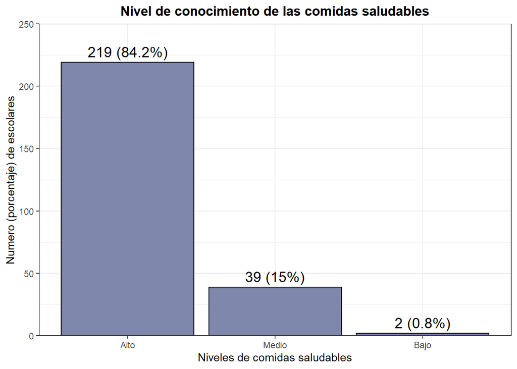

La distribución del nivel de conocimiento sobre comidas saludables entre los escolares muestra que la gran mayoría se encuentra en el nivel “Alto” con un 84.2% (n = 219), seguido por el nivel “Medio” con un 15% (n = 39) y, en menor medida, el nivel “Bajo” con apenas un 0.8% (n = 2). Estos resultados reflejan una notable concentración en el nivel más alto de conocimiento, indicando una tendencia positiva en la muestra estudiada. Sin embargo, la baja frecuencia en el nivel “Bajo” sugiere la existencia de un pequeño grupo vulnerable que podría beneficiarse de programas educativos focalizados.

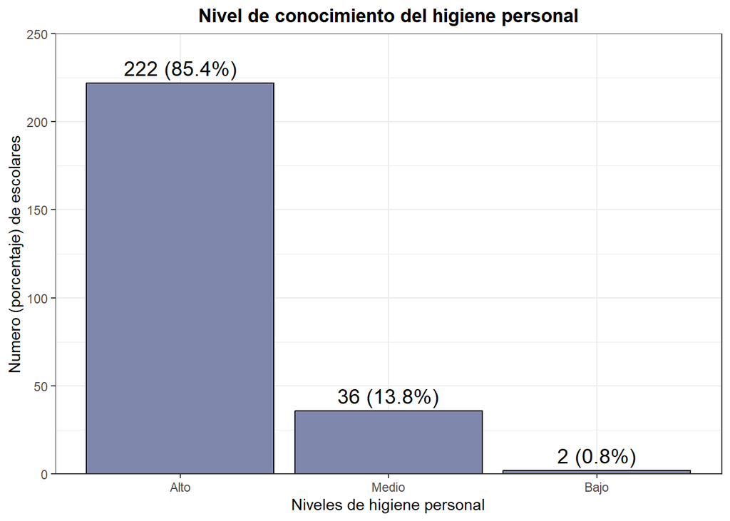

La distribución del nivel de conocimiento sobre higiene personal entre los escolares muestra que la gran mayoría se encuentra en el nivel “Alto”, representando el 85.4% (n = 222), seguido por el nivel “Medio” con un 13.8% (n = 36) y, en menor medida, el nivel “Bajo” con apenas un 0.8% (n = 2). Estos resultados reflejan una tendencia positiva, con una notable concentración en el nivel más alto de conocimiento, lo que indica un entendimiento sólido en la muestra estudiada. Sin embargo, la presencia de un pequeño grupo con niveles medio y bajo resalta la necesidad de implementar programas educativos focalizados para garantizar que todos los escolares alcancen un conocimiento adecuado sobre higiene personal.

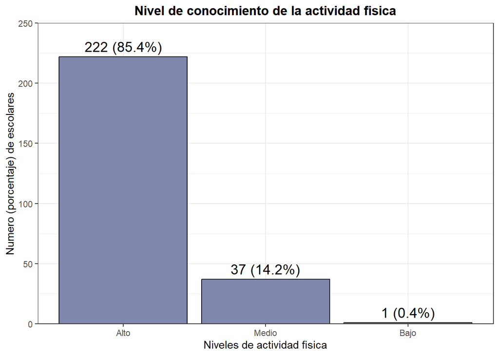

La distribución del nivel de conocimiento sobre la actividad física entre los escolares muestra que la gran mayoría se encuentra en el nivel “Alto”, representando el 85.4% (n = 222), seguido por el nivel “Medio” con un 14.2% (n = 37) y, en menor medida, el nivel “Bajo” con apenas un 0.4% (n = 1). Estos resultados reflejan una tendencia positiva, con una notable concentración en el nivel más alto de conocimiento, lo que indica un buen entendimiento sobre la importancia de la actividad física en esta población. No obstante, la presencia de un grupo pequeño con niveles medio y bajo sugiere la necesidad de estrategias específicas para garantizar que todos los escolares alcancen un nivel óptimo de conocimiento en esta área fundamental para la salud.

## Edad segun el nivel de conomiento de comida saludable, higiene personal y actividad fisica

|  | Conocimiento | Niveles | Media | Desviacion_Estandar | Mediana | Mínimo | Máximo | est_p_valor |
| --- | --- | --- | --- | --- | --- | --- | --- | --- |
| 1 | Comida Saludable | Alto | 9.72 | 0.93 | 10 | 8 | 11 | 4.7102 |
| 2 |  | Medio | 9.38 | 1.07 | 9 | 8 | 11 | ( 0.09 ) |
| 3 |  | Bajo | 9 | 0 | 9 | 9 | 9 |  |
| 4 | Higiene Personal | Alto | 9.69 | 0.95 | 10 | 8 | 11 | 3.4366 |
| 5 |  | Medio | 9.56 | 0.94 | 10 | 8 | 11 | ( 0.18 ) |
| 6 |  | Bajo | 8.5 | 0.71 | 8.5 | 8 | 9 |  |
| 7 | Actividad_fisica | Alto | 9.71 | 0.94 | 10 | 8 | 11 | 4.2446 |
| 8 |  | Medio | 9.35 | 1.03 | 9 | 8 | 11 | ( 0.12 ) |
| 9 |  | Bajo | 10 |  | 10 | 10 | 10 |  |

Ademas, la prueba de Kruskal-Wallis, indican que no existen diferencias estadísticamente significativas entre las distribuciones de edad en los niveles de conocimiento en Comida Saludable (p = 0.09), Higiene Personal (p = 0.18) y Actividad Física (p = 0.12). Esto sugiere que la variable Edad no está asociada significativamente con los niveles de conocimiento evaluados en estas áreas.

## Nivel de conocimiento de la comida saludable según el sexo

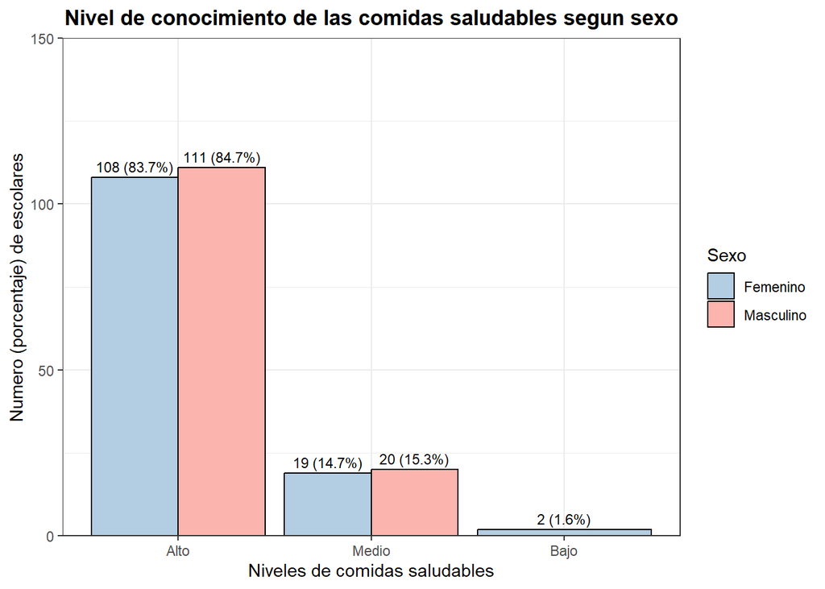

La distribución del nivel de conocimiento sobre comidas saludables según el sexo muestra que tanto en el grupo femenino como en el masculino, la mayoría de los escolares se encuentran en el nivel “Alto”, representando el 83.7% (n = 108) en el caso de las mujeres y el 84.7% (n = 111) en el caso de los hombres. En el nivel “Medio”, los porcentajes son comparables, con un 14.7% (n = 19) en mujeres y un 15.3% (n = 20) en hombres. Finalmente, el nivel “Bajo” es prácticamente inexistente, con solo 1.6% (n = 2) en el grupo femenino y ningún caso registrado en el grupo masculino.

```
##
##  Pearson's Chi-squared test with simulated p-value (based on 5000
##  replicates)
##
## data:  tabla
## X-squared = 2.0515, df = NA, p-value = 0.5077
```

La prueba Chi-cuadrado de Pearson, realizada con un p-valor simulado basado en 5000 réplicas, nos indica un p-valor de 0.5076985 , lo que podemos decir que no se encontraron diferencias estadísticamente significativas entre el sexo (femenino y masculino) y los niveles de conocimiento sobre comidas saludables (Alto, Medio, Bajo). Esto sugiere que los niveles de conocimiento sobre comidas saludables son similares entre ambos grupos de sexo en la muestra analizada.

## Nivel de conocimiento del higiene personal según el sexo

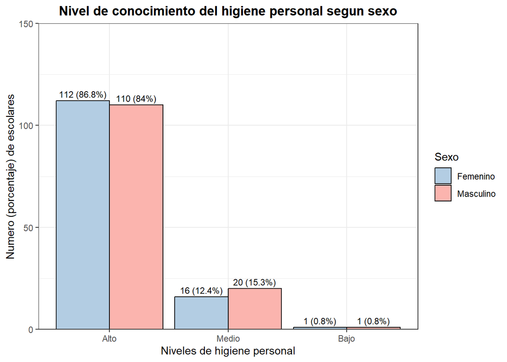

La distribución del nivel de conocimiento sobre higiene personal según el sexo muestra que tanto en el grupo femenino como en el masculino, la mayoría de los escolares se encuentra en el nivel “Alto”, representando el 86.8% (n = 112) para las mujeres y el 84% (n = 110) para los hombres. En el nivel “Medio”, los porcentajes son algo similares, con un 12.4% (n = 16) en mujeres y un 15.3% (n = 20) en hombres. Finalmente, en el nivel “Bajo”, ambos grupos tienen un 0.8% (n = 1).

```
##
##  Pearson's Chi-squared test with simulated p-value (based on 5000
##  replicates)
##
## data:  tabla
## X-squared = 0.4471, df = NA, p-value = 0.7964
```

La prueba Chi-cuadrado de Pearson, realizada con un p-valor simulado basado en 5000 réplicas, arrojó un p-valor de 0.7964407, lo que indica que no se encontraron diferencias estadísticamente significativas entre el sexo (femenino y masculino) y los niveles de conocimiento sobre higiene personal (Alto, Medio, Bajo). Esto sugiere que los niveles de conocimiento sobre higiene personal son similares entre ambos grupos de sexo en la muestra analizada, reforzando la idea de una distribución homogénea en cuanto al entendimiento de este tema dentro de la población estudiada.

## Nivel de conocimiento del actividad física según el sexo

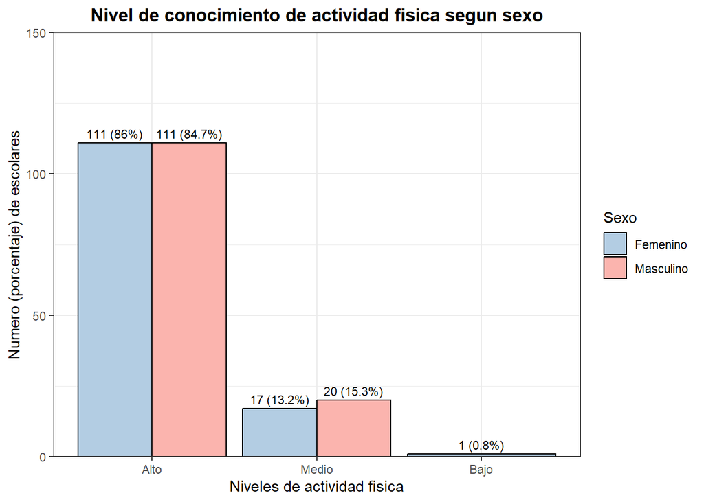

La distribución del nivel de conocimiento sobre actividad física según el sexo muestra que tanto en el grupo femenino como en el masculino, la mayoría de los escolares se encuentra en el nivel “Alto”, representando el 86% (n = 111) en las mujeres y el 84.7% (n = 111) en los hombres. En el nivel “Medio”, los porcentajes son similares, con un 13.2% (n = 17) en mujeres y un 15.3% (n = 20) en hombres. Finalmente, el nivel “Bajo” tiene una frecuencia muy baja, con solo un 0.8% (n = 1) en mujeres y ningún caso registrado en hombres.

```
##
##  Pearson's Chi-squared test with simulated p-value (based on 5000
##  replicates)
##
## data:  tabla
## X-squared = 1.2279, df = NA, p-value = 0.7203
```

La prueba Chi-cuadrado de Pearson, con un p-valor simulado basado en 5000 réplicas, obtuvo un p-valor de 0.7202559, lo cual indica que no existen diferencias estadísticamente significativas entre los niveles de conocimiento sobre actividad física (Alto, Medio, Bajo) y el sexo (femenino y masculino). Esto implica que ambos grupos presentan niveles similares de conocimiento en esta área, lo que refuerza la percepción de una distribución uniforme en el entendimiento de la actividad física dentro de la población evaluada.

## Análisis de asociación

```
##                                       Variables     Chi2    p_value
## X-squared  comida_saludable vs higiene_personal 70.25748 0.00079984
## X-squared1 comida_saludable vs actividad_fisica 52.48920 0.00659868
## X-squared2 higiene_personal vs actividad_fisica 34.05189 0.00699860
```

## Análisis de correspondencia

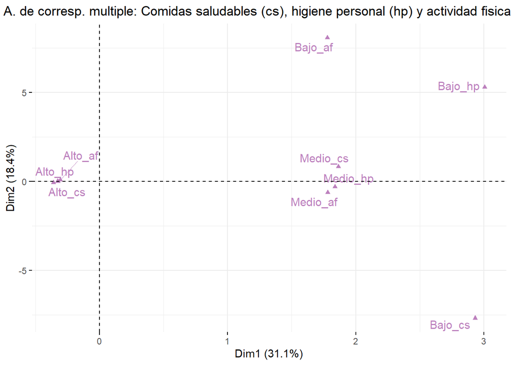

Este análisis de correspondencia múltiple proporciona información relevante sobre la relación entre los niveles de conocimiento en comidas saludables, higiene personal y actividad física. El eje horizontal (Dim1) explica el 31.1% de la varianza, mientras que el eje vertical (Dim2) explica el 18.4% de la varianza. Esto indica que gran parte de la información está capturada en la dimensión horizontal, pero la dimensión vertical también aporta una contribución notable.

En el gráfico, las categorías “Bajo” en las tres áreas (hp, af, cs) están más alejadas del origen, lo que sugiere que estas categorías son más distintivas y contribuyen significativamente a la diferenciación entre los grupos. Por otro lado, las categorías “Alto” en las tres áreas (hp, af, cs) están muy cercanas entre sí y próximas al origen, lo que indica una fuerte asociación entre altos niveles de conocimiento en estas áreas y una menor variabilidad dentro de esta categoría.

Las categorías “Medio” se encuentran entre las categorías “Alto” y “Bajo”, lo que sugiere una progresión ordenada desde “Bajo” hacia “Alto” a lo largo del eje horizontal. Esto puede interpretarse como un indicador de que, en general, los niveles de conocimiento en las tres áreas tienden a estar relacionados y progresan de forma conjunta.

En términos de asociación, las categorías “Bajo” de actividad física (Bajo_af) y de higiene personal (Bajo_hp) están cercanas, lo que sugiere una posible relación entre un bajo nivel de conocimiento en estas áreas. Sin embargo, Bajo_cs (comidas saludables) está algo más separado, indicando que los bajos niveles de conocimiento en esta área podrían no estar tan asociados con las otras. Las categorías “Medio” muestran relaciones más cercanas entre sí, indicando una asociación moderada en esta categoría intermedia.

En conclusión, el análisis muestra una fuerte relación entre altos niveles de conocimiento en las tres áreas, una diferenciación clara de los bajos niveles de conocimiento, y una progresión consistente en los niveles de conocimiento desde “Bajo” hacia “Alto”. Esto destaca la interdependencia entre estas áreas y refuerza la importancia de abordarlas de forma integrada en programas educativos.